# HAR_Analysis

Abhishek Ajmera

07/07/2020

# Summary:

## In this project I have performed analysis on Human activity recognition using the WLE dataset: http://groupware.les.inf.puc-rio.br/har#dataset. I first loaded the dataset into R. Then, I performed basic EDA on the dataset discovering the large number of missing values.I performed some cleansing and imputing operations.I then split the dataset into training and test tests. I trained 3 models - Random Forest (rf), Neural network and Gradient boosting machine(gbm) on the training set. After evaluating their prediction accuracy on the test set, I selected the rf model as my final model

# Background:

## Using devices such as Jawbone Up, Nike FuelBand, and Fitbit it is now possible to collect a large amount of data about personal activity relatively inexpensively. These type of devices are part of the quantified self movement – a group of enthusiasts who take measurements about themselves regularly to improve their health, to find patterns in their behavior, or because they are tech geeks. One thing that people regularly do is quantify how much of a particular activity they do, but they rarely quantify how well they do it. In this project, your goal will be to use data from accelerometers on the belt, forearm, arm, and dumbell of 6 participants. They were asked to perform barbell lifts correctly and incorrectly in 5 different ways. More information is available from the website here: http://groupware.les.inf.puc-rio.br/har

## Goal: The goal of the project is to predict the manner in which they did the exercise - classe variable

## Loading the dataset

```r
pml_training <- read.csv("C:/Users/Abhis/Downloads/pml-training.csv")
pml_testing <- read.csv("C:/Users/Abhis/Downloads/pml-testing.csv")
dim(pml_training)
```

```
## [1] 19622   160
```

### Looking at the distribution of missing data in the dataset:

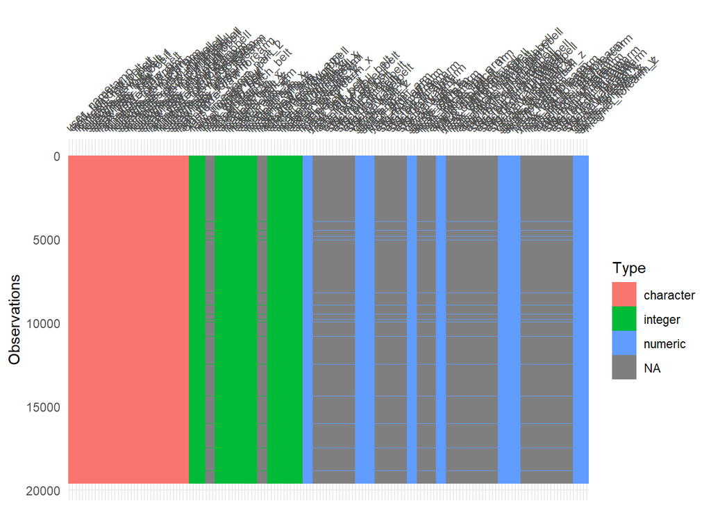

```r
library(visdat)
vis_dat(pml_training,warn_large_data = FALSE)
```

### From the above plot, we can see that for some columns, most of their data is NA. Interestingly, in these columns, actual data entries (Non-NA values) are for the entire row ie. for these columns having non-NA vlaue, that entire row has Non-NA values (complete rows).

### Now checking if there is a difference in the distribution of ‘classe’ comparing complete and incomplete cases

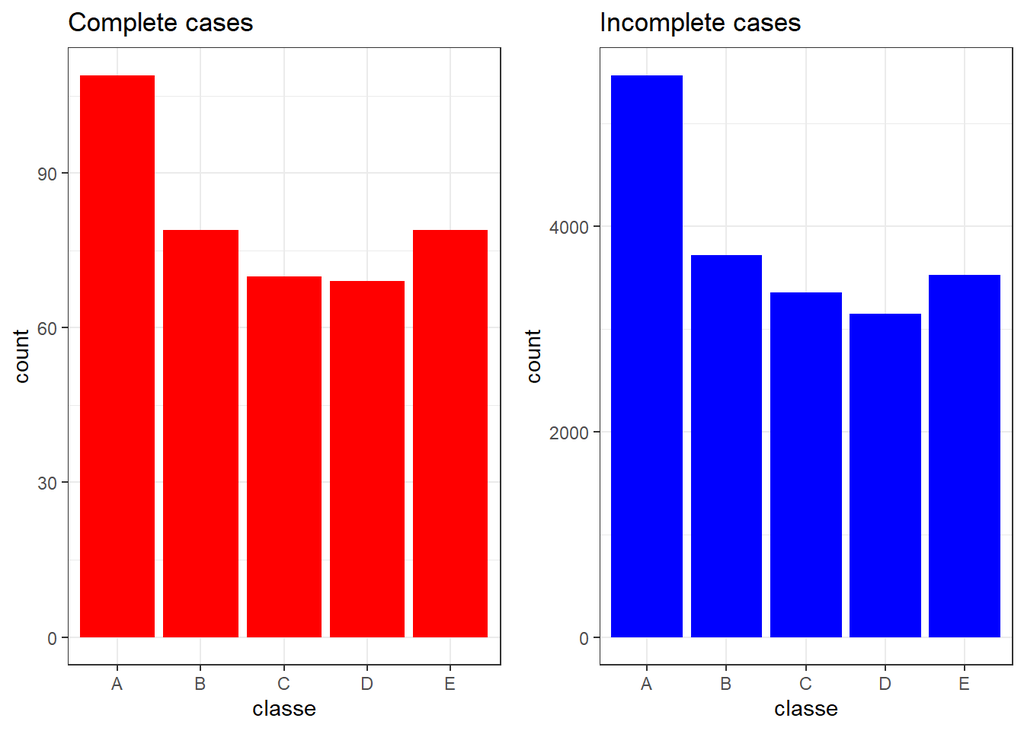

```r
library(ggplot2)
library(gridExtra)
a <-pml_training[complete.cases(pml_training),]
b <-pml_training[!complete.cases(pml_training),]
x=ggplot(aes(x=classe),data=a)+geom_bar(fill="red")+theme_bw()+ggtitle("Complete cases")
y=ggplot(aes(x=classe),data=b)+geom_bar(fill="blue")+theme_bw()+ggtitle("Incomplete cases")
grid.arrange(x, y, nrow = 1)
```

## From the above plot, the distribution of classe is similar.

## Looking at the nature of the dataset and the vast number of NAs I have decided that it would be prudent to replace these values with 0 as there are far fewer complete rows rows to make a prediction on the incomolete ones

```r
pml_training<-pml_training[,-c(1:5)]
sapply(pml_training,class)=="character"
```

[output not shown]

[output cut: 49 more lines]

[output not shown]

```r
pml_training[is.na(pml_training)] <- 0
library(caret)
head(nearZeroVar(pml_training,saveMetrics = TRUE))
```

```
##                  freqRatio percentUnique zeroVar   nzv
## new_window       47.330049    0.01019264   FALSE  TRUE
## num_window        1.000000    4.37264295   FALSE FALSE
## roll_belt         1.101904    6.77810621   FALSE FALSE
## pitch_belt        1.036082    9.37722964   FALSE FALSE
## yaw_belt          1.058480    9.97349913   FALSE FALSE
## total_accel_belt  1.063160    0.14779329   FALSE FALSE
```

### Removing variables having no variability and checking number of columns in new dataframe

```r
Now<-pml_training[,-nearZeroVar(pml_training)]
a<-data.frame(cbind(length(Now),length(pml_training)))
colnames(a)=c("New","Old")
a
```

```
##   New Old
## 1  54 155
```

### Creating data Partition - 60% Training 40 % Testing

```r
set.seed(123)
inTraining<-createDataPartition(Now$classe,p=0.6,list=FALSE)
Training=Now[inTraining,]
Testing=Now[-inTraining,]
```

## Training models:

### Random Forest Model (rf)

```r
set.seed(123)
rftrain=train(classe~.,data= Training,method="rf",,verbose=FALSE)
```

### Gradient boosting Machine (gbm)

```r
set.seed(123)
gbm_train<-train(classe~.,Training,verbose=FALSE,method="gbm")
```

### Neural Network

```r
set.seed(123)
nnetTrain<- train(classe~., data = Training, method = "nnet",verbose=FALSE)
```

## Predictions on test set

```r
set.seed(123)
Testing$classe=as.factor(Testing$classe)
rf_pred=predict(rftrain,Testing)
gbmpred=predict(gbm_train,Testing)
nnpred=predict(nnetTrain,Testing)
```

## Evaluating prediction accuracy

```r
confusionMatrix(nnpred,Testing$classe)
```

```
## Confusion Matrix and Statistics
##
##           Reference
## Prediction    A    B    C    D    E
##          A 1147   45   23    8   42
##          B   83  371   83  128  228
##          C  411  288  609  236  237
##          D    0    0    0    0    0
##          E  591  814  653  914  935
##
## Overall Statistics
##
##                Accuracy : 0.3903
##                  95% CI : (0.3794, 0.4012)
##     No Information Rate : 0.2845
##     P-Value [Acc > NIR] : < 2.2e-16
##
##                   Kappa : 0.2388
##
##  Mcnemar's Test P-Value : < 2.2e-16
##
## Statistics by Class:
##
##                      Class: A Class: B Class: C Class: D Class: E
## Sensitivity            0.5139  0.24440  0.44518   0.0000   0.6484
## Specificity            0.9790  0.91751  0.81908   1.0000   0.5359
## Pos Pred Value         0.9067  0.41545  0.34194      NaN   0.2393
## Neg Pred Value         0.8351  0.83504  0.87486   0.8361   0.8713
## Prevalence             0.2845  0.19347  0.17436   0.1639   0.1838
## Detection Rate         0.1462  0.04729  0.07762   0.0000   0.1192
## Detection Prevalence   0.1612  0.11382  0.22699   0.0000   0.4980
## Balanced Accuracy      0.7464  0.58096  0.63213   0.5000   0.5922
```

```r
confusionMatrix(rf_pred,Testing$classe)
```

```
## Confusion Matrix and Statistics
##
##           Reference
## Prediction    A    B    C    D    E
##          A 2231    3    0    0    0
##          B    0 1513    4    0    0
##          C    0    2 1364    0    0
##          D    0    0    0 1285    2
##          E    1    0    0    1 1440
##
## Overall Statistics
##
##                Accuracy : 0.9983
##                  95% CI : (0.9972, 0.9991)
##     No Information Rate : 0.2845
##     P-Value [Acc > NIR] : < 2.2e-16
##
##                   Kappa : 0.9979
##
##  Mcnemar's Test P-Value : NA
##
## Statistics by Class:
##
##                      Class: A Class: B Class: C Class: D Class: E
## Sensitivity            0.9996   0.9967   0.9971   0.9992   0.9986
## Specificity            0.9995   0.9994   0.9997   0.9997   0.9997
## Pos Pred Value         0.9987   0.9974   0.9985   0.9984   0.9986
## Neg Pred Value         0.9998   0.9992   0.9994   0.9998   0.9997
## Prevalence             0.2845   0.1935   0.1744   0.1639   0.1838
## Detection Rate         0.2843   0.1928   0.1738   0.1638   0.1835
## Detection Prevalence   0.2847   0.1933   0.1741   0.1640   0.1838
## Balanced Accuracy      0.9995   0.9980   0.9984   0.9995   0.9992
```

```r
confusionMatrix(gbmpred,Testing$classe)
```

```
## Confusion Matrix and Statistics
##
##           Reference
## Prediction    A    B    C    D    E
##          A 2226    9    0    4    1
##          B    6 1490   13    3    1
##          C    0   17 1350   14   10
##          D    0    2    5 1262   12
##          E    0    0    0    3 1418
##
## Overall Statistics
##
##                Accuracy : 0.9873
##                  95% CI : (0.9845, 0.9896)
##     No Information Rate : 0.2845
##     P-Value [Acc > NIR] : < 2.2e-16
##
##                   Kappa : 0.9839
##
##  Mcnemar's Test P-Value : NA
##
## Statistics by Class:
##
##                      Class: A Class: B Class: C Class: D Class: E
## Sensitivity            0.9973   0.9816   0.9868   0.9813   0.9834
## Specificity            0.9975   0.9964   0.9937   0.9971   0.9995
## Pos Pred Value         0.9938   0.9848   0.9705   0.9852   0.9979
## Neg Pred Value         0.9989   0.9956   0.9972   0.9963   0.9963
## Prevalence             0.2845   0.1935   0.1744   0.1639   0.1838
## Detection Rate         0.2837   0.1899   0.1721   0.1608   0.1807
## Detection Prevalence   0.2855   0.1928   0.1773   0.1633   0.1811
## Balanced Accuracy      0.9974   0.9890   0.9903   0.9892   0.9914
```

### Looking at the above tables , I choose the Random Forest model as the final model

## Now predicting on pml_testing

```r
Now2<-pml_testing[,-nearZeroVar(pml_testing)]
predict(rftrain,Now2)
```

```
##  [1] B A B A A E D B A A B C B A E E A B B B
## Levels: A B C D E
```

## Conclusion: I have selected the Random Forest model as my final model and have obtained 100% accuracy on the pml_testing dataset (Course project quiz)